# Antofagasta (ANFGF/ANTO)

Exploration, evaluation, development, and mining of copper properties in Chile and internationally.

- provides rail and road cargo
- rail and truck services to the mining industry in the Antofagasta Region
- subsidiary of Metalinvest Establishment
- 2020HY: production of 371,700 tonnes at $1.12/lb
- Large expansion of Los Pelambres and Centinela is coming
- Gold production: 282,300 oz per year
- Molybdenum production: 11,600 tonn per year

Chile mines:

- 60% interest in the Los Pelambres mine
- 70% interest in the Centinela mine
- 50% interest in the Zaldavar mine
- 70% interest in the Antucoya

Copper in general:

- CSG ESTIMATES A DEFICIT OF ABOUT 50,000 TONNES OF COPPER THIS YEAR AND A SURPLUS OF ABOUT 70,000 TONNES IN 2021 [mining.com](https://www.mining.com/global-copper-production-to-increase-in-2021-after-two-years-of-declines-icsg/)
- Additional output from new projects, including Tominskoye and Deziwa, coupled with that from ramp-up mines such as Cobre de Panama and a significant recovery in Indonesian output will partially offset the reductions resulting from the pandemic
- A global supply glut for the copper industry is expected for 2020 and 2021, due to the impacts of the COVID-19 pandemic, according to London-based International Wrought Copper Council [spglobal](https://www.spglobal.com/marketintelligence/en/news-insights/latest-news-headlines/global-copper-market-in-supply-glut-in-2020-2021-8211-iwcc-58811137)
- For 2021, the IWCC is expecting refined copper output to increase to 24.3 million tonnes, with a demand also increasing by 4.4% to 23.6 million tonnes

## News and Resources

-[2020 HY results](https://www.antofagasta.co.uk/media/3995/antofagasta-2020-hy-results-presentation-vf-website.pdf)

## Stats

As of 2021-01-04

- Market cap 20.3B
- Revenu around 1B/quater last 4 quaters

## Price

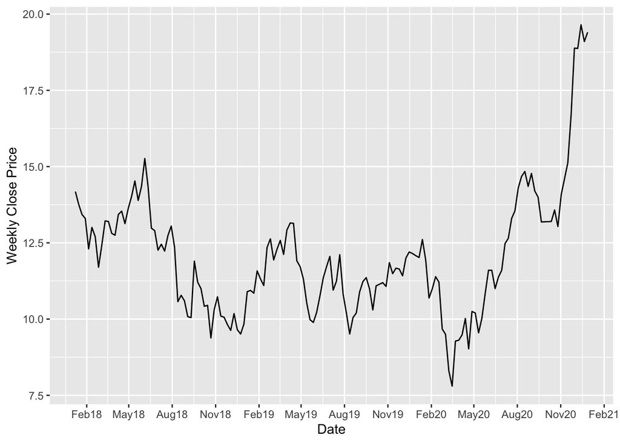

```
## [1] "Copper ETF: CPER"
```

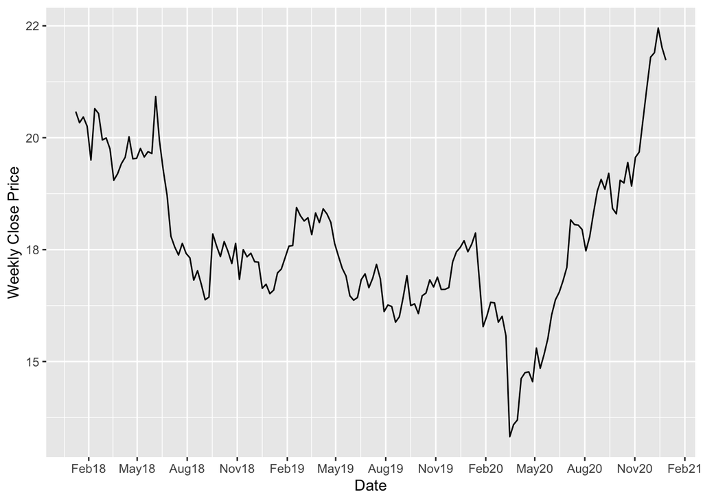

## Misc

[figure not shown]

[figure not shown]

[figure not shown]

[figure not shown]

[figure not shown]